# Risk Factor Analysis

## Outcome Variable

**Outcome Variable:** whz

## Predictor Variables

**Intervention Variable:** parity

**Adjustment Set:**

- arm
- W_mage
- meducyrs
- feducyrs
- hhwealth_quart
- W_mhtcm
- W_mwtkg
- W_mbmi
- vagbrth
- W_nrooms
- impsan
- delta_W_mage
- delta_meducyrs
- delta_feducyrs
- delta_hhwealth_quart
- delta_W_mhtcm
- delta_W_mwtkg
- delta_W_mbmi
- delta_vagbrth
- delta_W_nrooms
- delta_impsan

## Stratifying Variables

The analysis was stratified on these variable(s):

- agecat
- studyid
- country

## Data Summary

| agecat | studyid | country | parity | n_cell | n |
| --- | --- | --- | --- | --- | --- |
| Birth | COHORTS | GUATEMALA | 1 | 94 | 756 |
| Birth | COHORTS | GUATEMALA | 2 | 118 | 756 |
| Birth | COHORTS | GUATEMALA | 3+ | 544 | 756 |
| Birth | COHORTS | INDIA | 1 | 641 | 3855 |
| Birth | COHORTS | INDIA | 2 | 982 | 3855 |
| Birth | COHORTS | INDIA | 3+ | 2232 | 3855 |
| Birth | COHORTS | PHILIPPINES | 1 | 640 | 2899 |
| Birth | COHORTS | PHILIPPINES | 2 | 657 | 2899 |
| Birth | COHORTS | PHILIPPINES | 3+ | 1602 | 2899 |
| Birth | GMS-Nepal | NEPAL | 1 | 185 | 641 |
| Birth | GMS-Nepal | NEPAL | 2 | 169 | 641 |
| Birth | GMS-Nepal | NEPAL | 3+ | 287 | 641 |
| Birth | JiVitA-3 | BANGLADESH | 1 | 5520 | 18014 |
| Birth | JiVitA-3 | BANGLADESH | 2 | 6303 | 18014 |
| Birth | JiVitA-3 | BANGLADESH | 3+ | 6191 | 18014 |
| Birth | Keneba | GAMBIA | 1 | 146 | 1338 |
| Birth | Keneba | GAMBIA | 2 | 142 | 1338 |
| Birth | Keneba | GAMBIA | 3+ | 1050 | 1338 |
| Birth | PROVIDE | BANGLADESH | 1 | 202 | 532 |
| Birth | PROVIDE | BANGLADESH | 2 | 182 | 532 |
| Birth | PROVIDE | BANGLADESH | 3+ | 148 | 532 |
| Birth | SAS-CompFeed | INDIA | 1 | 304 | 1103 |
| Birth | SAS-CompFeed | INDIA | 2 | 258 | 1103 |
| Birth | SAS-CompFeed | INDIA | 3+ | 541 | 1103 |
| Birth | ZVITAMBO | ZIMBABWE | 1 | 5561 | 12916 |
| Birth | ZVITAMBO | ZIMBABWE | 2 | 3882 | 12916 |
| Birth | ZVITAMBO | ZIMBABWE | 3+ | 3473 | 12916 |
| 6 months | COHORTS | GUATEMALA | 1 | 132 | 963 |
| 6 months | COHORTS | GUATEMALA | 2 | 139 | 963 |
| 6 months | COHORTS | GUATEMALA | 3+ | 692 | 963 |

[output cut: 57 more lines]

The following strata were considered:

- agecat: 24 months, studyid: COHORTS, country: GUATEMALA
- agecat: 24 months, studyid: COHORTS, country: INDIA
- agecat: 24 months, studyid: COHORTS, country: PHILIPPINES
- agecat: 24 months, studyid: GMS-Nepal, country: NEPAL
- agecat: 24 months, studyid: JiVitA-3, country: BANGLADESH
- agecat: 24 months, studyid: Keneba, country: GAMBIA
- agecat: 24 months, studyid: PROVIDE, country: BANGLADESH
- agecat: 24 months, studyid: TanzaniaChild2, country: TANZANIA, UNITED REPUBLIC OF
- agecat: 24 months, studyid: ZVITAMBO, country: ZIMBABWE
- agecat: 6 months, studyid: COHORTS, country: GUATEMALA
- agecat: 6 months, studyid: COHORTS, country: INDIA
- agecat: 6 months, studyid: COHORTS, country: PHILIPPINES
- agecat: 6 months, studyid: GMS-Nepal, country: NEPAL
- agecat: 6 months, studyid: JiVitA-3, country: BANGLADESH
- agecat: 6 months, studyid: Keneba, country: GAMBIA
- agecat: 6 months, studyid: PROVIDE, country: BANGLADESH
- agecat: 6 months, studyid: SAS-CompFeed, country: INDIA
- agecat: 6 months, studyid: SAS-FoodSuppl, country: INDIA
- agecat: 6 months, studyid: TanzaniaChild2, country: TANZANIA, UNITED REPUBLIC OF
- agecat: 6 months, studyid: ZVITAMBO, country: ZIMBABWE
- agecat: Birth, studyid: COHORTS, country: GUATEMALA
- agecat: Birth, studyid: COHORTS, country: INDIA
- agecat: Birth, studyid: COHORTS, country: PHILIPPINES
- agecat: Birth, studyid: GMS-Nepal, country: NEPAL
- agecat: Birth, studyid: JiVitA-3, country: BANGLADESH
- agecat: Birth, studyid: Keneba, country: GAMBIA
- agecat: Birth, studyid: PROVIDE, country: BANGLADESH
- agecat: Birth, studyid: SAS-CompFeed, country: INDIA
- agecat: Birth, studyid: ZVITAMBO, country: ZIMBABWE

### Dropped Strata

Some strata were dropped due to rare outcomes:

- agecat: 24 months, studyid: TanzaniaChild2, country: TANZANIA, UNITED REPUBLIC OF

## Methods Detail

We’re interested in the causal parameters $E[Y_a]$ for all values of $a \in \mathcal{A}$. These parameters represent the mean outcome if, possibly contrary to fact, we intervened to set all units to have $A=a$. Under the randomization and positivity assumptions, these are identified by the statistical parameters $\psi_a=E_W[E_{Y|A,W}(Y|A=a,W)]$. In addition, we’re interested in the mean of $Y$, $E[Y]$ under no intervention (the observed mean). We will estimate these parameters by using SuperLearner to fit the relevant likelihood factors – $E_{Y|A,W}(Y|A=a,W)$ and $p(A=a|W)$, and then updating our likelihood fit using a joint TMLE.

For unadjusted analyses ($W=\{\}$), initial likelihoods were estimated using Lrnr_glm to estimate the simple $E(Y|A)$ and Lrnr_mean to estimate $p(A)$. For adjusted analyses, a small library containing Lrnr_glmnet, Lrnr_xgboost, and Lrnr_mean was used.

Having estimated these parameters, we will then use the delta method to estimate relative risks and attributable risks relative to a prespecified baseline level of $A$.

# Results Detail

## Results Plots

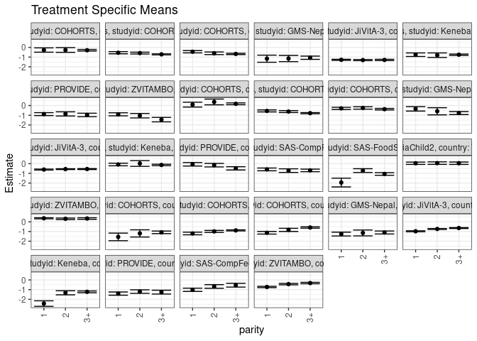

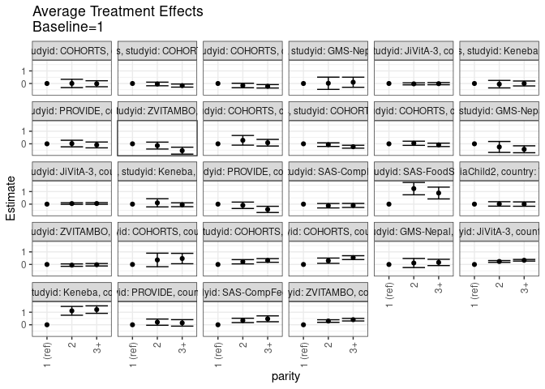

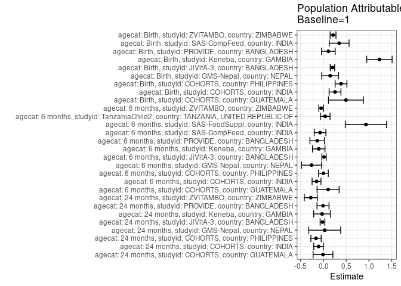

## Results Table

### Parameter: TSM

| agecat | studyid | country | intervention_level | baseline_level | estimate | ci_lower | ci_upper |
| --- | --- | --- | --- | --- | --- | --- | --- |
| Birth | COHORTS | GUATEMALA | 1 | NA | -1.5564901 | -1.9475674 | -1.1654129 |
| Birth | COHORTS | GUATEMALA | 2 | NA | -1.1980470 | -1.5690546 | -0.8270394 |
| Birth | COHORTS | GUATEMALA | 3+ | NA | -1.0854133 | -1.2182345 | -0.9525920 |
| Birth | COHORTS | INDIA | 1 | NA | -1.2041561 | -1.3391972 | -1.0691150 |
| Birth | COHORTS | INDIA | 2 | NA | -0.9902339 | -1.0934579 | -0.8870099 |
| Birth | COHORTS | INDIA | 3+ | NA | -0.8856255 | -0.9384875 | -0.8327634 |
| Birth | COHORTS | PHILIPPINES | 1 | NA | -1.1291604 | -1.2641459 | -0.9941750 |
| Birth | COHORTS | PHILIPPINES | 2 | NA | -0.8326563 | -0.9952277 | -0.6700849 |
| Birth | COHORTS | PHILIPPINES | 3+ | NA | -0.5878584 | -0.6616386 | -0.5140782 |
| Birth | GMS-Nepal | NEPAL | 1 | NA | -1.2634469 | -1.4595769 | -1.0673170 |
| Birth | GMS-Nepal | NEPAL | 2 | NA | -1.1482574 | -1.4516182 | -0.8448966 |
| Birth | GMS-Nepal | NEPAL | 3+ | NA | -1.1028915 | -1.2564066 | -0.9493764 |
| Birth | JiVitA-3 | BANGLADESH | 1 | NA | -0.9758639 | -1.0261237 | -0.9256040 |
| Birth | JiVitA-3 | BANGLADESH | 2 | NA | -0.7396415 | -0.7909917 | -0.6882912 |
| Birth | JiVitA-3 | BANGLADESH | 3+ | NA | -0.6442600 | -0.6884587 | -0.6000613 |
| Birth | Keneba | GAMBIA | 1 | NA | -2.4334661 | -2.7154882 | -2.1514441 |
| Birth | Keneba | GAMBIA | 2 | NA | -1.3240994 | -1.5336958 | -1.1145031 |
| Birth | Keneba | GAMBIA | 3+ | NA | -1.2258665 | -1.3183882 | -1.1333448 |
| Birth | PROVIDE | BANGLADESH | 1 | NA | -1.4065478 | -1.5727336 | -1.2403620 |
| Birth | PROVIDE | BANGLADESH | 2 | NA | -1.1988416 | -1.3794309 | -1.0182522 |
| Birth | PROVIDE | BANGLADESH | 3+ | NA | -1.2577494 | -1.4542941 | -1.0612047 |
| Birth | SAS-CompFeed | INDIA | 1 | NA | -1.0150420 | -1.1829514 | -0.8471327 |
| Birth | SAS-CompFeed | INDIA | 2 | NA | -0.6698803 | -0.8552059 | -0.4845546 |
| Birth | SAS-CompFeed | INDIA | 3+ | NA | -0.5412823 | -0.7353494 | -0.3472152 |
| Birth | ZVITAMBO | ZIMBABWE | 1 | NA | -0.7265934 | -0.7958914 | -0.6572955 |
| Birth | ZVITAMBO | ZIMBABWE | 2 | NA | -0.4301973 | -0.5057340 | -0.3546605 |
| Birth | ZVITAMBO | ZIMBABWE | 3+ | NA | -0.3215754 | -0.3954123 | -0.2477385 |
| 6 months | COHORTS | GUATEMALA | 1 | NA | 0.0911254 | -0.1561828 | 0.3384337 |
| 6 months | COHORTS | GUATEMALA | 2 | NA | 0.3700458 | 0.0745029 | 0.6655887 |
| 6 months | COHORTS | GUATEMALA | 3+ | NA | 0.1783729 | 0.0842325 | 0.2725132 |

[output cut: 54 more lines]

### Parameter: E(Y)

| agecat | studyid | country | intervention_level | baseline_level | estimate | ci_lower | ci_upper |
| --- | --- | --- | --- | --- | --- | --- | --- |
| Birth | COHORTS | GUATEMALA | NA | NA | -1.0621429 | -1.1631387 | -0.9611471 |
| Birth | COHORTS | INDIA | NA | NA | -0.9498080 | -0.9874148 | -0.9122013 |
| Birth | COHORTS | PHILIPPINES | NA | NA | -0.7427251 | -0.7890855 | -0.6963647 |
| Birth | GMS-Nepal | NEPAL | NA | NA | -1.1164431 | -1.2040134 | -1.0288728 |
| Birth | JiVitA-3 | BANGLADESH | NA | NA | -0.7778272 | -0.7968313 | -0.7588232 |
| Birth | Keneba | GAMBIA | NA | NA | -1.2037220 | -1.2694226 | -1.1380213 |
| Birth | PROVIDE | BANGLADESH | NA | NA | -1.2984586 | -1.3752758 | -1.2216415 |
| Birth | SAS-CompFeed | INDIA | NA | NA | -0.6700453 | -0.8474950 | -0.4925957 |
| Birth | ZVITAMBO | ZIMBABWE | NA | NA | -0.5156349 | -0.5414936 | -0.4897762 |
| 6 months | COHORTS | GUATEMALA | NA | NA | 0.1940810 | 0.1226351 | 0.2655269 |
| 6 months | COHORTS | INDIA | NA | NA | -0.7068611 | -0.7417800 | -0.6719423 |
| 6 months | COHORTS | PHILIPPINES | NA | NA | -0.2938433 | -0.3352064 | -0.2524802 |
| 6 months | GMS-Nepal | NEPAL | NA | NA | -0.6038416 | -0.6899448 | -0.5177384 |
| 6 months | JiVitA-3 | BANGLADESH | NA | NA | -0.5935161 | -0.6130518 | -0.5739805 |
| 6 months | Keneba | GAMBIA | NA | NA | -0.1873900 | -0.2456638 | -0.1291162 |
| 6 months | PROVIDE | BANGLADESH | NA | NA | -0.1990907 | -0.2817968 | -0.1163845 |
| 6 months | SAS-CompFeed | INDIA | NA | NA | -0.6657084 | -0.8024377 | -0.5289791 |
| 6 months | SAS-FoodSuppl | INDIA | NA | NA | -1.0121579 | -1.1280429 | -0.8962729 |
| 6 months | TanzaniaChild2 | TANZANIA, UNITED REPUBLIC OF | NA | NA | 0.0797179 | 0.0266621 | 0.1327737 |
| 6 months | ZVITAMBO | ZIMBABWE | NA | NA | 0.3106432 | 0.2849661 | 0.3363203 |
| 24 months | COHORTS | GUATEMALA | NA | NA | -0.2813755 | -0.3354674 | -0.2272835 |
| 24 months | COHORTS | INDIA | NA | NA | -0.6564729 | -0.6914450 | -0.6215007 |
| 24 months | COHORTS | PHILIPPINES | NA | NA | -0.6099592 | -0.6467541 | -0.5731643 |
| 24 months | GMS-Nepal | NEPAL | NA | NA | -1.1363107 | -1.2252817 | -1.0473398 |
| 24 months | JiVitA-3 | BANGLADESH | NA | NA | -1.2978031 | -1.3210763 | -1.2745298 |
| 24 months | Keneba | GAMBIA | NA | NA | -0.7834078 | -0.8357743 | -0.7310414 |
| 24 months | PROVIDE | BANGLADESH | NA | NA | -0.8928670 | -0.9755153 | -0.8102187 |
| 24 months | ZVITAMBO | ZIMBABWE | NA | NA | -1.1817824 | -1.2809226 | -1.0826422 |

### Parameter: ATE

| agecat | studyid | country | intervention_level | baseline_level | estimate | ci_lower | ci_upper |
| --- | --- | --- | --- | --- | --- | --- | --- |
| Birth | COHORTS | GUATEMALA | 1 | 1 | 0.0000000 | 0.0000000 | 0.0000000 |
| Birth | COHORTS | GUATEMALA | 2 | 1 | 0.3584431 | -0.1798258 | 0.8967121 |
| Birth | COHORTS | GUATEMALA | 3+ | 1 | 0.4710769 | 0.0575647 | 0.8845891 |
| Birth | COHORTS | INDIA | 1 | 1 | 0.0000000 | 0.0000000 | 0.0000000 |
| Birth | COHORTS | INDIA | 2 | 1 | 0.2139222 | 0.0438523 | 0.3839921 |
| Birth | COHORTS | INDIA | 3+ | 1 | 0.3185306 | 0.1734492 | 0.4636121 |
| Birth | COHORTS | PHILIPPINES | 1 | 1 | 0.0000000 | 0.0000000 | 0.0000000 |
| Birth | COHORTS | PHILIPPINES | 2 | 1 | 0.2965041 | 0.0853206 | 0.5076876 |
| Birth | COHORTS | PHILIPPINES | 3+ | 1 | 0.5413020 | 0.3874173 | 0.6951868 |
| Birth | GMS-Nepal | NEPAL | 1 | 1 | 0.0000000 | 0.0000000 | 0.0000000 |
| Birth | GMS-Nepal | NEPAL | 2 | 1 | 0.1151895 | -0.2457983 | 0.4761773 |
| Birth | GMS-Nepal | NEPAL | 3+ | 1 | 0.1605554 | -0.0887041 | 0.4098149 |
| Birth | JiVitA-3 | BANGLADESH | 1 | 1 | 0.0000000 | 0.0000000 | 0.0000000 |
| Birth | JiVitA-3 | BANGLADESH | 2 | 1 | 0.2362224 | 0.1641564 | 0.3082883 |
| Birth | JiVitA-3 | BANGLADESH | 3+ | 1 | 0.3316039 | 0.2660096 | 0.3971982 |
| Birth | Keneba | GAMBIA | 1 | 1 | 0.0000000 | 0.0000000 | 0.0000000 |
| Birth | Keneba | GAMBIA | 2 | 1 | 1.1093667 | 0.7585162 | 1.4602173 |
| Birth | Keneba | GAMBIA | 3+ | 1 | 1.2075997 | 0.9098834 | 1.5053159 |
| Birth | PROVIDE | BANGLADESH | 1 | 1 | 0.0000000 | 0.0000000 | 0.0000000 |
| Birth | PROVIDE | BANGLADESH | 2 | 1 | 0.2077062 | -0.0374306 | 0.4528430 |
| Birth | PROVIDE | BANGLADESH | 3+ | 1 | 0.1487984 | -0.1087800 | 0.4063768 |
| Birth | SAS-CompFeed | INDIA | 1 | 1 | 0.0000000 | 0.0000000 | 0.0000000 |
| Birth | SAS-CompFeed | INDIA | 2 | 1 | 0.3451618 | 0.1721253 | 0.5181983 |
| Birth | SAS-CompFeed | INDIA | 3+ | 1 | 0.4737598 | 0.2409037 | 0.7066158 |
| Birth | ZVITAMBO | ZIMBABWE | 1 | 1 | 0.0000000 | 0.0000000 | 0.0000000 |
| Birth | ZVITAMBO | ZIMBABWE | 2 | 1 | 0.2963961 | 0.1939220 | 0.3988703 |
| Birth | ZVITAMBO | ZIMBABWE | 3+ | 1 | 0.4050180 | 0.3037946 | 0.5062415 |
| 6 months | COHORTS | GUATEMALA | 1 | 1 | 0.0000000 | 0.0000000 | 0.0000000 |
| 6 months | COHORTS | GUATEMALA | 2 | 1 | 0.2789204 | -0.1060661 | 0.6639068 |
| 6 months | COHORTS | GUATEMALA | 3+ | 1 | 0.0872474 | -0.1771552 | 0.3516500 |

[output cut: 54 more lines]

### Parameter: PAR

| agecat | studyid | country | intervention_level | baseline_level | estimate | ci_lower | ci_upper |
| --- | --- | --- | --- | --- | --- | --- | --- |
| Birth | COHORTS | GUATEMALA | 1 | NA | 0.4943473 | 0.1105611 | 0.8781334 |
| Birth | COHORTS | INDIA | 1 | NA | 0.2543481 | 0.1244866 | 0.3842096 |
| Birth | COHORTS | PHILIPPINES | 1 | NA | 0.3864354 | 0.2569835 | 0.5158872 |
| Birth | GMS-Nepal | NEPAL | 1 | NA | 0.1470039 | -0.0377735 | 0.3317812 |
| Birth | JiVitA-3 | BANGLADESH | 1 | NA | 0.1980366 | 0.1492810 | 0.2467922 |
| Birth | Keneba | GAMBIA | 1 | NA | 1.2297442 | 0.9512199 | 1.5082684 |
| Birth | PROVIDE | BANGLADESH | 1 | NA | 0.1080891 | -0.0417199 | 0.2578982 |
| Birth | SAS-CompFeed | INDIA | 1 | NA | 0.3449967 | 0.1267147 | 0.5632787 |
| Birth | ZVITAMBO | ZIMBABWE | 1 | NA | 0.2109586 | 0.1461966 | 0.2757206 |
| 6 months | COHORTS | GUATEMALA | 1 | NA | 0.1029556 | -0.1391818 | 0.3450929 |
| 6 months | COHORTS | INDIA | 1 | NA | -0.1516274 | -0.2494755 | -0.0537793 |
| 6 months | COHORTS | PHILIPPINES | 1 | NA | 0.0000507 | -0.1062918 | 0.1063933 |
| 6 months | GMS-Nepal | NEPAL | 1 | NA | -0.2616398 | -0.4833370 | -0.0399426 |
| 6 months | JiVitA-3 | BANGLADESH | 1 | NA | 0.0132271 | -0.0343014 | 0.0607555 |
| 6 months | Keneba | GAMBIA | 1 | NA | -0.1027540 | -0.2402666 | 0.0347585 |
| 6 months | PROVIDE | BANGLADESH | 1 | NA | -0.1363268 | -0.2962533 | 0.0235997 |
| 6 months | SAS-CompFeed | INDIA | 1 | NA | -0.0743930 | -0.2025306 | 0.0537446 |
| 6 months | SAS-FoodSuppl | INDIA | 1 | NA | 0.9335564 | 0.4796129 | 1.3874999 |
| 6 months | TanzaniaChild2 | TANZANIA, UNITED REPUBLIC OF | 1 | NA | 0.0383731 | -0.0687500 | 0.1454962 |
| 6 months | ZVITAMBO | ZIMBABWE | 1 | NA | -0.0495689 | -0.1013591 | 0.0022213 |
| 24 months | COHORTS | GUATEMALA | 1 | NA | -0.0097586 | -0.2271566 | 0.2076393 |
| 24 months | COHORTS | INDIA | 1 | NA | -0.1067377 | -0.2126781 | -0.0007972 |
| 24 months | COHORTS | PHILIPPINES | 1 | NA | -0.1625015 | -0.2757402 | -0.0492628 |
| 24 months | GMS-Nepal | NEPAL | 1 | NA | 0.0281187 | -0.3226496 | 0.3788871 |
| 24 months | JiVitA-3 | BANGLADESH | 1 | NA | -0.0203536 | -0.0723723 | 0.0316650 |
| 24 months | Keneba | GAMBIA | 1 | NA | -0.0311291 | -0.2140586 | 0.1518004 |
| 24 months | PROVIDE | BANGLADESH | 1 | NA | -0.0090384 | -0.1412603 | 0.1231834 |
| 24 months | ZVITAMBO | ZIMBABWE | 1 | NA | -0.2775115 | -0.4205149 | -0.1345081 |